# Causal Machine Learning for Dynamic Pricing

## A DML-IV Approach to Retail Optimization

## Project Summary

This project evaluates the use of Double Machine Learning with Instrumental Variables (DML-IV) for causal retail demand estimation under endogenous price determination. Using transactional retail scanner data, the analysis compares a traditional fixed-effects two-stage least squares (2SLS) framework against a DML-IV specification designed to recover nonlinear and heterogeneous price responses across consumer income segments.

Price endogeneity is addressed in both frameworks using wholesale costs as an instrumental variable, while the DML-IV specification additionally incorporates machine learning nuisance models to capture nonlinear relationships and variation in price responsiveness across market segments. Estimated elasticities are validated and translated into two simulated pricing strategies: a direct elasticity-based pricing approach and a bounded income-based pricing approach.

Results show that while both frameworks produce credible causal estimates, DML-IV captures nonlinear differences in price sensitivity across consumer segments that are largely missed by the simpler linear 2SLS model. Pricing simulations indicate that the direct elasticity-based approach suggests substantial pricing opportunity but becomes less reliable when recommending prices far outside historically observed levels, while the bounded income-based strategy produces more moderate and operationally credible profit improvements. These findings demonstrate how causal machine learning can extend conventional econometric pricing analysis by enabling richer behavioral insight and more practically implementable segment-aware pricing decisions.

## 1. Data Acquisition & Preparation

This analysis utilizes the Dominick’s Finer Foods scanner dataset, a widely used retail panel dataset containing store-level transaction records from the Chicago metropolitan area spanning approximately September 1989 through May 1997. While the full database contains nearly 100 million observations across 29 consumer packaged goods categories, this study focuses exclusively on the beer category, yielding approximately 1.8 million weekly store-product observations.

The beer category was selected due to its substantial pricing variation, strong cross-brand competition, and suitability for estimating heterogeneous price elasticity responses across income-defined retail markets.

## 1.1 Raw Data Loading & Dataset Integration

Dataset construction integrates four primary source files, each contributing distinct components required to build the analytical panel:

- **wber.csv** — weekly beer sales transactions including units sold, retail prices, margins, and promotional indicators
- **weeks.csv** — calendar structure and event timing information
- **upcber_with_brand_category.csv** — product-level metadata including package size, ounce volume, and brand classification
- **demo.csv** — store-level demographic characteristics used for heterogeneity estimation

These files are merged into a unified store-product-week panel after applying initial quality-control filters and excluding invalid pricing observations. A wholesale cost measure is then recovered using observed retail price and markup information, providing the instrumental variable used to address endogenous pricing.

**▶ Show/Hide Data Configuration Code**

```
# =========================
# Data Configuration
# =========================

# =========================
# Environment Setup
# =========================

import numpy as np
import pandas as pd
import gc

# =========================
# Raw Data Loading
# =========================

move_cols = [
    'STORE', 'UPC', 'WEEK',
    'MOVE', 'PRICE', 'PROFIT', 'SALE', 'OK'
]
move = pd.read_csv('datasets/wber.csv', usecols=move_cols)

upc_cols = ['UPC', 'BRAND', 'OZ', 'PACK', 'CATEGORY']
upc = pd.read_csv('datasets/upcber_with_brand_category.csv', usecols=upc_cols)

demo_cols = ['STORE', 'INCOME', 'AGE60', 'UNEMP', 'EDUC']
demo = pd.read_csv('datasets/demo.csv', usecols=demo_cols)

weeks = pd.read_csv(
    'datasets/weeks.csv',
    names=['WEEK', 'START', 'END', 'EVENT']
)

# =========================
# Initial Data Cleaning
# =========================

# Keep only quality-approved observations
move = move[(move['OK'] == 1) & (move['PRICE'] > 0)].copy()

# Construct wholesale cost (instrument)
move['COST'] = move['PRICE'] * (1 - (move['PROFIT'] / 100))

# Clean sale flags
move['SALE'] = move['SALE'].fillna('0')

# =========================
# Dataset Integration
# =========================

df = (
    move
    .merge(upc, on='UPC', how='inner')
    .merge(weeks[['WEEK', 'START']], on='WEEK', how='inner')
    .merge(demo, on='STORE', how='left')
)

del move, upc, demo, weeks
_ = gc.collect()
```

## 1.2 Core Feature Engineering

Several economically meaningful transformations are constructed to support causal estimation. Prices and costs are normalized on a per-ounce basis to better reflect consumer purchasing decisions, while logarithmic transformations stabilize variance and permit elasticity-based coefficient interpretation.

Income is standardized to produce a zero-centered heterogeneity feature, improving numerical stability and enabling heterogeneous elasticity estimates to be interpreted relative to the average-income store environment.

**▶ Show/Hide Core Feature Engineering code**

```
# =========================
# Core Feature Engineering
# =========================

# Date processing
df['START'] = pd.to_datetime(df['START'], format='%m/%d/%y')
df['MONTH'] = df['START'].dt.month

# Sort for panel consistency
df = df.sort_values(['UPC', 'STORE', 'WEEK']).reset_index(drop=True)

# Fill baseline categorical states
df['SALE'] = df['SALE'].fillna('0')

# Sales indicators
df['SALE_B'] = (df['SALE'] == 'B').astype(int)
df['SALE_C'] = (df['SALE'] == 'C').astype(int)
df['SALE_S'] = (df['SALE'] == 'S').astype(int)

# Unit scaling
df['TOTAL_OZ'] = df['OZ'] * df['PACK']

# Price and quantity transformations
df['price_per_oz'] = df['PRICE'] / df['TOTAL_OZ']
df['cost_per_oz'] = df['COST'] / df['TOTAL_OZ']

df['ln_price_per_oz'] = np.log(df['price_per_oz'])
df['ln_cost_per_oz'] = np.log(df['cost_per_oz'].where(df['cost_per_oz'] > 0))
df['ln_move'] = np.log(df['MOVE'])
df['ln_income'] = np.log(df['INCOME'].replace(0, np.nan))
df['ln_oz'] = np.log(df['OZ'])

# Income standardization
df['ln_income_std'] = (
    (df['ln_income'] - df['ln_income'].mean()) /
    df['ln_income'].std()
)

# Interaction terms
df['income_x_unemp'] = df['ln_income_std'] * df['UNEMP']

# =========================
# Categorical Consolidation
# =========================

# Brand grouping
brand_share = df['BRAND'].value_counts(normalize=True)
top_brands = brand_share[brand_share >= 0.01].index.tolist()
top_brands = [b for b in top_brands if b != 'OTHER']

df['BRAND_GROUP'] = np.where(
    df['BRAND'].isin(top_brands),
    df['BRAND'],
    'OTHER'
)

# Pack grouping
pack_share = df['PACK'].value_counts(normalize=True)
top_packs = pack_share[pack_share > 0.02].index

df['PACK_GROUP'] = df['PACK'].where(
    df['PACK'].isin(top_packs),
    'OTHER'
)
```

## 1.3 Competitive Price Construction

To account for strategic substitution effects, competitor pricing measures are constructed using within-store cross-product pricing information. Primary competitor prices are computed at the weekly store-category level, with monthly fallback aggregation used when within-week competitor observations are unavailable.

This control captures local competitive pricing pressure and improves identification of own-price demand effects.

**▶ Show/Hide Competitive Price Construction Code**

```
# =========================
# Competitive Price Construction
# =========================

# Primary within-store/week/category competitor price
grp = df.groupby(['STORE', 'WEEK', 'CATEGORY'])['price_per_oz']

sum_price = grp.transform('sum')
count = grp.transform('count')

comp_price_level = (sum_price - df['price_per_oz']) / (count - 1)
comp_price_level = comp_price_level.where(count > 1)

# Fallback within-store/month/category
fallback_grp = df.groupby(['STORE', 'MONTH', 'CATEGORY'])['price_per_oz']

fallback_sum = fallback_grp.transform('sum')
fallback_count = fallback_grp.transform('count')

fallback_level = (fallback_sum - df['price_per_oz']) / (fallback_count - 1)
fallback_level = fallback_level.where(fallback_count > 1)

# Combine
comp_price_level_final = comp_price_level.combine_first(fallback_level)

# Log transform
comp_price_level_final = comp_price_level_final.where(comp_price_level_final > 0)
df['comp_price'] = np.log(comp_price_level_final)

# Fill residual missing values
df['comp_price'] = df['comp_price'].fillna(df['ln_price_per_oz'])

# =========================
# Final Analytical Cleaning
# =========================

df = df.dropna().reset_index(drop=True)
```

## 1.4 Analytical Dataset Assembly

Following feature construction, all required modeling variables are extracted into a dedicated analytical dataset (**model_df**). Intermediate objects are removed from memory to maintain computational efficiency during large-scale estimation.

Sparse dummy encoding is then applied to categorical controls, allowing rich fixed-effect structure to be retained while intermediery objects are removed as well to preserve memory efficiency.

**▶ Show/Hide Analytical Dataset Assembly Code**

```
# =========================
# Analytical Dataset Assembly
# =========================

model_cols = [
    'ln_move',
    'ln_price_per_oz',
    'ln_cost_per_oz',
    'ln_income_std',
    'AGE60',
    'ln_oz',
    'CATEGORY',
    'SALE_B',
    'SALE_C',
    'SALE_S',
    'comp_price',
    'STORE',
    'BRAND',
    'BRAND_GROUP',
    'PACK_GROUP',
    'MONTH',
    'PACK',
    'UNEMP',
    'EDUC',
    'PRICE',
    'COST',
    'MOVE',
    'UPC',
    'WEEK',
    'INCOME'
]

model_df = df[model_cols]

del df
gc.collect()

# =========================
# Fixed Effects Encoding
# =========================

brand_dummies = pd.get_dummies(
    model_df['BRAND_GROUP'],
    prefix='brand',
    dtype='uint8',
    sparse=True,
    drop_first=True
)

pack_dummies = pd.get_dummies(
    model_df['PACK_GROUP'],
    prefix='pack',
    dtype='uint8',
    sparse=True,
    drop_first=True
)

month_dummies = pd.get_dummies(
    model_df['MONTH'],
    prefix='month',
    dtype='uint8',
    sparse=True,
    drop_first=True
)

# Store column names
brand_cols = brand_dummies.columns.tolist()
pack_cols = pack_dummies.columns.tolist()
month_cols = month_dummies.columns.tolist()

# Concatenate
model_df = pd.concat([
    model_df,
    brand_dummies,
    pack_dummies,
    month_dummies,
], axis=1)

del brand_dummies
del pack_dummies
del month_dummies

_ = gc.collect()
```

## 2. Modeling Methodology

This analysis compares a traditional econometric instrumental variable framework with a causal machine learning approach for estimating retail price elasticity under endogenous pricing. Both estimation strategies are implemented using an identical causal design, ensuring that performance differences reflect methodological differences in estimation rather than variation in variable selection or identification structure.

The comparison evaluates a fixed-effects two-stage least squares (2SLS) benchmark against Double Machine Learning with Instrumental Variables (DML-IV), allowing assessment of whether flexible machine learning nuisance estimation improves elasticity recovery relative to conventional linear IV estimation.

## 2.1 Variable Specification

The causal specification is held constant across both frameworks.

- **Outcome (Y):** `ln_move` — log quantity sold
- **Treatment (T/X):** `ln_price_per_oz` — log retail price per ounce
- **Instrument (Z):** `ln_cost_per_oz` — log wholesale cost per ounce
- **Heterogeneity Feature:** `ln_income_std` — standardized log household income
- **Core Controls:** `ln_income_std`, `ln_oz`, `AGE60`, `UNEMP`, `EDUC`, `SALE_B`, `SALE_C`, `SALE_S`, `comp_price`
- **Fixed Effects Controls:** `brand_cols`, `pack_cols`, `month_cols` — brand, package-size, and monthly seasonal indicators

Additional fixed effects were evaluated through robustness testing to determine whether their computational cost justified inclusion.

Store fixed effects were assessed using matched-sample robustness testing. Their inclusion produced only marginal attenuation in estimated elasticity (approximately 1%), indicating that cross-store heterogeneity is already largely captured through demographic and competitive controls. Given their substantial computational burden at this scale, store fixed effects were excluded from the final specification.

Event fixed effects were also evaluated as supplemental temporal controls. Their inclusion produced only a negligible elasticity shift (approximately −0.900 to −0.907), suggesting limited explanatory power beyond monthly seasonal controls.

This specification captures product-level pricing dynamics, local demographic heterogeneity, competitive substitution effects, and recurring seasonal purchasing patterns, while supporting a parsimonious final specification that balances identification strength with computational tractability.

## 2.2 Price Endogeneity

Price endogeneity arises when retail prices are correlated with unobserved demand shocks, making it difficult to determine whether changes in demand are caused by price itself or by the underlying demand shocks influencing price. For example, retailers may raise prices ahead of long weekends or major holidays when demand is expected to increase. If sales remain elevated, it becomes difficult to determine whether demand is responding to price itself or to the anticipated demand shock influencing that pricing decision

This creates a causal identification problem, as standard regression cannot separate the effect of price from these confounding demand factors. Instrumental variable estimation through two-stage least squares (2SLS) addresses this challenge.

## 2.3 Traditional Econometric Benchmark: 2SLS

Two-stage least squares (2SLS) addresses price endogeneity through a sequential estimation process that uses wholesale cost as an instrumental variable to isolate retail price variation driven by wholesale cost shocks rather than underlying demand conditions, allowing causal identification of the price effect on demand

In the first stage, retail prices are regressed on wholesale cost and exogenous controls to isolate this instrument-driven price variation. In the second stage, this isolated price variation is used to estimate its effect on demand, allowing causal identification of the price effect.

The first-stage pricing equation is specified as:

$$ \ln(T_{it}) = \pi_0 + \pi_1 \ln(Z_{it}) + W_{it}'\pi + u_{it} $$

*Where:*

- $T_{it}$ denotes retail price per ounce for product *i* in period *t*
- $Z_{it}$ represents wholesale cost per ounce (instrument)
- $W_{it}$ is the vector of observed controls and fixed effects
- $u_{it}$ is the first-stage error term

In the second stage, this predicted exogenous price component is substituted into the structural demand equation to recover a consistent causal estimate of price elasticity.

$$ \ln(Y_{it}) = \beta_0 + \beta_1 \widehat{\ln(T_{it})} + W_{it}'\beta + \epsilon_{it} $$

*Where:*

- $Y_{it}$ denotes quantity sold
- $\widehat{\ln(T_{it})}$ is the instrumented predicted log price
- $\beta_1$ is the estimated own-price elasticity
- $\epsilon_{it}$ is the structural demand error term

This framework provides the primary econometric benchmark against which the DML-IV approach is evaluated.

## 2.4 Causal Machine Learning Framework: DML-IV

Double Machine Learning with Instrumental Variables (DML-IV) extends the traditional instrumental variable framework by using machine learning to flexibly model relationships between observed controls and the outcome, treatment, and instrument.

Unlike traditional two-stage least squares (2SLS), where these relationships must be explicitly specified, DML-IV learns them directly from the data before performing instrumental variable estimation.

The core idea is to first remove predictable variation in demand, price, and wholesale cost explained by observed controls, and then estimate causal elasticity using the remaining variation.

The term “double” reflects the integration of two complementary components: machine learning for flexible estimation of nuisance relationships, and orthogonal econometric estimation that makes the final causal estimate less sensitive to small prediction errors.

**2.4.1 Stage 1: Learn Predictable Structure**

Machine learning models estimate systematic patterns in demand, price, and wholesale cost explained by observed controls. These intermediate models are referred to as nuisance functions. These functions capture structured variation attributable to observed controls and must be removed prior to causal estimation.

$$ m(W_{it}) = E[Q_{it} \mid W_{it}] $$

$$ g(W_{it}) = E[P_{it} \mid W_{it}] $$

$$ r(W_{it}) = E[C_{it} \mid W_{it}] $$

*Where:*

- $Y_{it}$ denotes log quantity sold
- $T_{it}$ denotes log retail price per ounce
- $Z_{it}$ denotes log wholesale cost per ounce
- $W_{it}$ is the vector of observed controls and fixed effects

**2.4.2 Stage 2: Remove Predictable Variation**

The predicted components are then subtracted from the observed data to isolate the unexplained residual variation. This strips away predictable movement driven by observed controls, leaving a cleaner residual signal for instrumental variable estimation.

$$ \tilde{Y}_{it} = Y_{it} - \hat{m}(W_{it}) $$

$$ \tilde{T}_{it} = T_{it} - \hat{g}(W_{it}) $$

$$ \tilde{Z}_{it} = Z_{it} - \hat{r}(W_{it}) $$

*Where:*

- $\tilde{Y}_{it}$ is residualized demand
- $\tilde{T}_{it}$ is residualized price
- $\tilde{Z}_{it}$ is residualized instrument

**2.4.3 Stage 3: Estimate Causal Elasticity Using Orthogonal Moment Estimation**

Following residualization, solving an instrumental variable moment condition, analogous to applying classical two-stage least squares to the residualized data, isolates price variation driven by wholesale cost shocks, allowing estimation of the causal effect of price on demand.

$$ E\left[\tilde{Z}_{it}\left(\tilde{Y}_{it} - \theta \tilde{T}_{it}\right)\right] = 0 $$

*Where:*

- $\theta$ is the estimated causal elasticity parameter

In practical terms, once the correct elasticity has been estimated, residual wholesale cost shocks should no longer explain any remaining residual demand variation.

All nuisance functions are estimated using XGBoost, selected for its ability to capture nonlinear interactions while remaining computationally efficient for large-scale panel data.

Cross-fitting generates out-of-sample nuisance predictions, while orthogonalization ensures small prediction errors have minimal influence on the final elasticity estimate.

This combines the interpretability of classical IV estimation with the flexibility of machine learning-based confounding control.

## 2.5 Comparative Estimation Design

Both frameworks use identical treatment, instrument, control, and heterogeneity specifications, ensuring that differences in estimated elasticity primarily reflect methodological distinctions between conventional linear IV and causal machine learning estimation.

This design enables direct evaluation of whether DML-IV’s flexible nuisance estimation captures nonlinear heterogeneity that may be obscured under conventional linear econometric specifications.

## 3. Model Implementation Pipeline

Model implementation for both 2SLS and DML-IV is standardized through custom estimation wrappers designed to improve computational efficiency when working with large-scale panel data. This design facilitates repeated estimation, robustness testing, and hyperparameter experimentation within a consistent modeling workflow.

## 3.1 2SLS Model Implementation

The 2SLS estimation wrapper was implemented using NumPy arrays rather than the DataFrame-based linearmodels.iv package to reduce memory overhead and improve performance for repeated large-scale estimation.

**▶ Show/Hide 2SLS Estimation Wrapper Code**

```
# =========================
# 2SLS Estimation Wrapper
# =========================

def run_2sls_full(Y, T, Z, W):
    """
    Returns:
        beta_second : second-stage coefficients
        X_second    : second-stage design matrix
    """
    # First stage
    ZW = np.hstack([Z, W])
    beta_first = np.linalg.lstsq(ZW, T, rcond=None)[0]
    T_hat = ZW @ beta_first

    # Second stage
    X_second = np.hstack([T_hat, W])
    beta_second = np.linalg.lstsq(X_second, Y, rcond=None)[0]

    return beta_second, X_second


def robust_se(Y, X, beta):
    """
    HC1 robust standard errors
    """
    residuals = Y - X @ beta

    XtX_inv = np.linalg.pinv(X.T @ X)

    u = residuals.reshape(-1, 1)
    meat = (X * u).T @ (X * u)

    n, k = X.shape
    meat *= (n / (n - k))

    vcov = XtX_inv @ meat @ XtX_inv

    return np.sqrt(np.diag(vcov))
```

Using the treatment, instrument, outcome, and control variables specified in the variable selection section, the estimation wrapper executes the full sequential 2SLS procedure, first isolating instrument-driven price variation and then estimating its effect on demand.

**▶ Show/Hide 2SLS Model Run Code**

```
# =========================
# 2SLS Model Run
# =========================

# Outcome
Y_2sls = model_df['ln_move'].values.astype(np.float32)

# Endogenous variables
T_2sls = np.column_stack([
    model_df['ln_price_per_oz'].values,
    (model_df['ln_price_per_oz'] * model_df['ln_income_std']).values
]).astype(np.float32)

# Instruments
Z_2sls = np.column_stack([
    model_df['ln_cost_per_oz'].values,
    (model_df['ln_cost_per_oz'] * model_df['ln_income_std']).values
]).astype(np.float32)

# Controls
W_base_cols_2sls = [
    'ln_oz', 'AGE60',
    'SALE_B', 'SALE_C', 'SALE_S',
    'UNEMP', 'EDUC',
    'ln_income_std',
    'comp_price'
]

W_base_2sls = model_df[
    W_base_cols_2sls
].values.astype(np.float32)

# Fixed effects
FE = model_df[
    brand_cols + pack_cols + month_cols
].values.astype(np.float32)

# Intercept
n = Y_2sls.shape[0]
const = np.ones((n, 1), dtype=np.float32)

# Final control matrix
W_2sls = np.hstack([const, W_base_2sls, FE])

# Run 2SLS
beta_second, X_second = run_2sls_full(
    Y_2sls,
    T_2sls,
    Z_2sls,
    W_2sls
)
```

## 3.2 DML-IV Model Implementation

A corresponding estimation wrapper was developed for DML-IV to encapsulate model execution and define the XGBoost learner configuration used for nuisance estimation. Primary hyperparameter selections are specified within the wrapper, with tuning rationale discussed in the following section.

**▶ Show/Hide Define DML-IV Model Code**

```
# =========================
#  Define DML Model
# =========================

# Import Modeling Packages
from xgboost import XGBRegressor
from econml.iv.dml import DMLIV
from econml.inference import BootstrapInference

# MakeXGB function
def make_xgb(seed):
    return XGBRegressor(
        n_estimators=500,
        learning_rate=0.05,
        max_depth=4,
        min_child_weight=100,
        subsample=0.8,
        colsample_bytree=0.8,
        reg_lambda=3.0,
        reg_alpha=2.0,
        tree_method='hist',
        max_bin=256,
        random_state=seed,
        n_jobs=-1
    )

# Construct DML vatiables from dataset
# 1. Build variables (pandas)
Y = model_df['ln_move']
T = model_df[['ln_price_per_oz']]
Z = model_df[['ln_cost_per_oz']]
X = model_df[['ln_income_std']]

W_dml_cols = ['ln_oz', 'AGE60', 'UNEMP', 'EDUC',
     'SALE_B', 'SALE_C', 'SALE_S', 'comp_price']

W = model_df[
    W_dml_cols
    + brand_cols
    + pack_cols
    + month_cols
]

# 2. Convert to numpy BEFORE fitting
Y_dml = Y.to_numpy()

T_dml = T.to_numpy(dtype=np.float32)
Z_dml = Z.to_numpy(dtype=np.float32)
X_dml = X.to_numpy(dtype=np.float32)
W_dml = W.to_numpy(dtype=np.float32)
```

Using the same treatment, instrument, outcome, and control specification as the 2SLS framework, the DML estimation wrapper executes model estimation under the causal machine learning framework.

**▶ Show/Hide RUN DML-IV Model Code**

```
# =========================
# RUN DML-IV Model
# =========================

#  Initialize the DML-IV Estimator
# We must use KEYWORD arguments (model_y=...) to satisfy the modern EconML API
est = DMLIV(
    model_y_xw = make_xgb(41),
    model_t_xw = make_xgb(42),
    model_t_xwz = make_xgb(43),
    discrete_treatment=False,
    cv=5
)

# Fit the Engine
est.fit(Y_dml, T_dml, Z=Z_dml, X=X_dml, W=W_dml, inference=BootstrapInference(n_bootstrap_samples=1))
print("SUCCESS: Model Trained!")
```

## 4. Hyperparameter Selection for XGBoost Learners

Because DML-IV relies on machine learning nuisance estimation, hyperparameter selection directly influences the flexibility of residualization and, consequently, the stability of estimated causal elasticity. Hyperparameter tuning was therefore conducted to balance model flexibility against estimation stability, with parameter choices selected at points where additional complexity produced diminishing marginal gains in elasticity performance.

Unlike conventional predictive tuning focused solely on minimizing out-of-sample prediction error, hyperparameter selection was evaluated using elasticity attenuation behavior and subsample stability across repeated estimation runs.

## 4.1 Parameters Evaluated

Primary tuning focused on four XGBoost hyperparameters governing model complexity and regularization:

- **Tree depth** (`max_depth`), controlling interaction complexity and nonlinear representational capacity
- **Number of estimators** (`n_estimators`), governing ensemble size and boosting refinement
- **Learning rate** (`learning_rate`), controlling gradient update magnitude during optimization
- **Minimum child weight** (`min_child_weight`), imposing regularization through minimum leaf partition size

These four parameters were prioritized because they most directly govern model flexibility, regularization strength, and nonlinear signal capture within the nuisance learners. Remaining hyperparameters were held at conventional benchmark values, as their influence on elasticity behavior is generally secondary relative to the primary complexity-controlling parameters evaluated here.

Each parameter was varied independently while holding all remaining hyperparameters constant to isolate its marginal effect on elasticity estimation.

## 4.2 Tuning Criteria

Hyperparameter selection was guided by two criteria designed to balance model flexibility against causal stability. Unlike standard predictive tuning, which prioritizes forecast accuracy, DML-IV tuning focuses on how effectively nuisance models remove confounding. Insufficient flexibility can leave nonlinear confounding in the residuals, while excessive flexibility can overfit the noise, destabilizing the residualized variation used for causal estimation.

- **Elasticity Responsiveness**: Evaluates whether increasing model flexibility yields meaningful shifts in the estimated elasticity. It ensures the models capture necessary nonlinear confounding structures rather than introducing complexity that does not contribute to bias reduction.
- **Subsample Stability**: Assesses the consistency of estimates across repeated subsamples. This confirms that the observed elasticity reflects a stable underlying signal rather than artifacts or "noise" introduced by an over-parameterized nuisance model.

Together, these criteria manage the tradeoff between capturing the signal and maintaining the robustness of the final causal estimate.

Across alternative tuning specifications, subsample stability showed no material improvement beyond candidate elasticity inflection points. Hyperparameters were therefore selected at these inflection points, balancing nonlinear flexibility against diminishing returns from additional complexity.

## 4.3 Hyperparameter Tuning Results

Hyperparameter sensitivity curves were evaluated across the four primary parameters of focus. Candidate values were assessed using elasticity responsiveness to identify observed elasticity elbows, with minimum child weight selected at the upper threshold of the stable elasticity region.

**▶ Show/Hide Hyperparameter Tuning Curves Code**

```
# =========================
# Hyperparameter Tuning Curves
# ============================================

import matplotlib.pyplot as plt
import numpy as np

fig, axs = plt.subplots(2, 2, figsize=(16, 11))

# --------------------------------------------
# Tree Depth
# --------------------------------------------
x = np.array([2, 3, 4, 5, 6])
y = np.array([-0.517, -0.766, -0.956, -1.068, -1.145])

axs[0, 0].plot(x, y, linewidth=2.5, color='black')
axs[0, 0].axvline(4, linestyle='--', alpha=0.6)
axs[0, 0].text(4.1, -0.60, 'Selected: 4', fontsize=10)

axs[0, 0].set_title('Tree Depth Sensitivity', fontsize=14)
axs[0, 0].set_xlabel('Max Depth', fontsize=12)
axs[0, 0].set_ylabel('Estimated Elasticity', fontsize=12)
axs[0, 0].grid(True, alpha=0.25)
axs[0, 0].set_xlim(2, 6)
axs[0, 0].set_ylim(-1.2, -0.45)

# --------------------------------------------
# Number of Estimators
# --------------------------------------------
x = np.array([100, 250, 500, 750, 1000])
y = np.array([-0.737, -0.832, -0.963, -1.029, -1.074])

axs[0, 1].plot(x, y, linewidth=2.5, color='black')
axs[0, 1].axvline(500, linestyle='--', alpha=0.6)
axs[0, 1].text(520, -0.79, 'Selected: 500', fontsize=10)

axs[0, 1].set_title('Estimator Count Sensitivity', fontsize=14)
axs[0, 1].set_xlabel('Number of Trees', fontsize=12)
axs[0, 1].set_ylabel('Estimated Elasticity', fontsize=12)
axs[0, 1].grid(True, alpha=0.25)
axs[0, 1].set_xlim(100, 1000)

# --------------------------------------------
# Learning Rate
# --------------------------------------------
x = np.array([0.01, 0.03, 0.05, 0.07, 0.10])
y = np.array([-0.744, -0.843, -0.963, -1.017, -1.072])

axs[1, 0].plot(x, y, linewidth=2.5, color='black')
axs[1, 0].axvline(0.05, linestyle='--', alpha=0.6)
axs[1, 0].text(0.052, -0.79, 'Selected: 0.05', fontsize=10)

axs[1, 0].set_title('Learning Rate Sensitivity', fontsize=14)
axs[1, 0].set_xlabel('Learning Rate', fontsize=12)
axs[1, 0].set_ylabel('Estimated Elasticity', fontsize=12)
axs[1, 0].grid(True, alpha=0.25)
axs[1, 0].set_xlim(0.01, 0.10)

# --------------------------------------------
# Min Child Weight
# --------------------------------------------
x = np.array([10, 25, 50, 100, 150, 300, 500, 700])
y = np.array([-0.957, -0.960, -0.963, -0.963, -0.956, -0.946, -0.931, -0.915])

axs[1, 1].plot(x, y, linewidth=2.5, color='black')
axs[1, 1].axvline(100, linestyle='--', alpha=0.6)
axs[1, 1].text(165, -0.922, 'Selected: 100', fontsize=10)

axs[1, 1].set_title('Min Child Weight Sensitivity', fontsize=14)
axs[1, 1].set_xlabel('Min Child Weight', fontsize=12)
axs[1, 1].set_ylabel('Estimated Elasticity', fontsize=12)
axs[1, 1].grid(True, alpha=0.25)
axs[1, 1].set_xlim(10, 700)
axs[1, 1].set_ylim(-0.97, -0.91)

# --------------------------------------------
# Final Layout
# --------------------------------------------
fig.suptitle('DML-IV Hyperparameter Tuning Curves', fontsize=18, y=1.02)

plt.tight_layout()
plt.show()
```

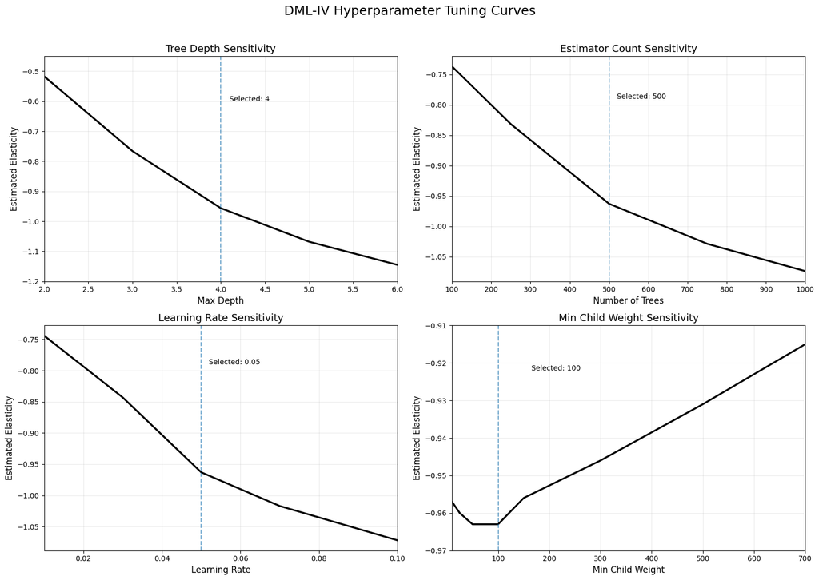

Selected Hyperparameters

| Parameter | Selected Value | Selection Basis |
| --- | --- | --- |
| Tree Depth | 4 | Observed elasticity elbow |
| Number of Estimators | 500 | Ensemble response elbow |
| Learning Rate | 0.05 | Optimization refinement elbow |
| Minimum Child Weight | 100 | Upper elasticity stabilization threshold |

**Interpretation:**  
Across all tuning dimensions, elasticity curves exhibited clear regions of diminishing marginal response beyond the selected parameter values. Additional model complexity produced limited elasticity refinement and no material improvement in subsample stability. This consistent pattern indicates that selected hyperparameters capture the relevant nonlinear causal structure while avoiding unnecessary complexity that could increase estimation variance without improving causal identification.  
While tree depth, estimator count, and learning rate exhibited clear elasticity elbows, minimum child weight displayed a stable elasticity plateau followed by upward elasticity drift beyond the selected threshold, identifying it as the highest regularization value that preserved stable elasticity behavior.

## 5. Estimation Results

Estimation results are presented through overall elasticity estimates and income-interaction effects under each estimation framework. Overall elasticity estimates capture average consumer price responsiveness, while interaction effects measure how elasticity varies with income. Heterogeneity results further examine subgroup elasticity differences across low- and high-income consumer segments to evaluate whether aggregate estimates mask meaningful variation across purchasing power groups. Understanding these differences is particularly important for pricing strategy, as income-dependent elasticity patterns may indicate opportunities for more targeted pricing decisions. Elasticity comparisons are further visualized to facilitate direct interpretation of framework-specific heterogeneity patterns.

## 5.1 Overall Elasticities

**▶ Show/Hide 2SLS Model Results Code**

```
# =========================
# 2SLS Model Results
# ========================

# Extract coefficients
elasticity_2sls = beta_second[0]
elasticity_interaction_2sls = beta_second[1]

# Robust SE + CI
se = robust_se(Y_2sls, X_second, beta_second)

se_price = se[0]

z_score = 1.96

ci_lower_2sls = float(elasticity_2sls - z_score * se_price)
ci_upper_2sls = float(elasticity_2sls + z_score * se_price)
```

**▶ Show/Hide DML Model Results Code**

```
# =========================
# DML Model Results
# =========================

# Define elasticity for comparison later
elasticity_dml = float(np.squeeze(est.intercept_))
elasticity_interaction_dml = float(np.squeeze(est.coef_))

# Baseline elasticity CI
ci_lower_dml, ci_upper_dml = est.effect_interval(X_dml)

ci_lower_dml = float(ci_lower_dml.mean())
ci_upper_dml = float(ci_upper_dml.mean())
```

**▶ Show/Hide 2SLS & DML-IV Elasticity Estimation Results Code**

```
# =========================
# 2SLS & DML-IV Elasticity Estimation Results
# =========================

elasticity_results = pd.DataFrame({
    "2SLS": [
        float(elasticity_2sls),
        f"[{ci_lower_2sls:.3f}, {ci_upper_2sls:.3f}]",
        float(elasticity_interaction_2sls)
    ],
    "DML-IV": [
        float(elasticity_dml),
        f"[{ci_lower_dml:.3f}, {ci_upper_dml:.3f}]",
        float(elasticity_interaction_dml)
    ]
},
index=[
    "Elasticity",
    "95% Confidence Interval",
     "Income Interaction Elasticity",
])

elasticity_results

display(
    elasticity_results.style
    .format({
        "2SLS": lambda x: f"{x:.2f}" if isinstance(x, float) else x,
        "DML-IV": lambda x: f"{x:.2f}" if isinstance(x, float) else x
    })
    .set_caption("Elasticity Estimation Results")
    .set_table_styles([
        {
            'selector': 'caption',
            'props': [
                ('text-align', 'Center'),
                ('font-size', '16px'),
                ('font-weight', 'bold'),
                ('margin-bottom', '10px')
            ]
        },
        {
            'selector': '',
            'props': [
                ('margin-left', 'auto'),
                ('margin-right', 'auto')
            ]
        }
    ])
)
```

Elasticity Estimation Results

|  | 2SLS | DML-IV |
| --- | --- | --- |
| Elasticity | -0.59 | -0.96 |
| 95% Confidence Interval | [-0.603, -0.585] | [-0.962, -0.962] |
| Income Interaction Elasticity | -0.01 | 0.20 |

**Interpretation:**

Elasticities are negative under both estimation frameworks, indicating that price increases reduce product demand as expected. DML-IV produces a substantially larger elasticity estimate than 2SLS, suggesting stronger estimated consumer price responsiveness after accounting for nonlinear confounding structure.

The income interaction results further highlight important differences across frameworks. While confidence intervals are reported only for average elasticity estimates due to inference limitations under the fitted DML-IV interaction specification, the interaction point estimates remain informative for comparative interpretation. The near-zero interaction estimated under 2SLS suggests minimal income-based heterogeneity in price responsiveness. In contrast, the positive interaction estimated under DML-IV indicates that elasticity becomes less negative as income increases, implying greater price sensitivity among lower-income consumers and weaker responsiveness among higher-income consumers.

These results suggest that DML-IV captures economically meaningful heterogeneity that is largely obscured under the linear 2SLS specification. The observed pattern of greater price sensitivity among lower-income consumers is consistent with standard demand theory, lending additional economic plausibility to the nonlinear heterogeneity recovered through the more flexible causal machine learning framework.

## 5.2 Income Heterogeneity

**▶ Show/Hide 2SLS Income Heterogeneity Run Code**

```
# =========================
# 2SLS Income Heterogeneity Run
# =========================

# Extract coefficients from fitted IV model
beta_0 = beta_second[0]
beta_1 = beta_second[1]

# Split data by median income
median_inc = model_df['ln_income_std'].median()

low_inc = model_df[model_df['ln_income_std'] <= median_inc]
high_inc = model_df[model_df['ln_income_std'] > median_inc]

# Compute elasticity for each group
elasticity_low_2sls = (beta_0 + beta_1 * low_inc['ln_income_std']).mean()
elasticity_high_2sls = (beta_0 + beta_1 * high_inc['ln_income_std']).mean()
```

**▶ Show/Hide DML-IV Income Heterogeneity Run Code**

```
# =========================
# DML-IV Income Heterogeneity Run
# =========================

# Split data by median income
median_inc = model_df['ln_income_std'].median()
low_inc = model_df[model_df['ln_income_std'] <= median_inc]
high_inc = model_df[model_df['ln_income_std'] > median_inc]

# Run a quick check on the effect for both
elasticity_low_dml = est.effect(low_inc[['ln_income_std']]).mean()
elasticity_high_dml = est.effect(high_inc[['ln_income_std']]).mean()
```

**▶ Show/Hide 2SLS & DML-IV Income Heterogeneity Results Code**

```
# =========================
# 2SLS & DML-IV Income Heterogeneity Results
# =========================

heter_results = pd.DataFrame({
    "2SLS": [
        float(elasticity_low_2sls),
        float(elasticity_high_2sls)
    ],
    "DML-IV": [
        float(elasticity_low_dml),
        float(elasticity_high_dml)
    ]
},
index=[
    "Elasticity (Low Income)",
    "Elasticity (High Income)"
])

heter_results

display(
    heter_results.style
    .format({
        "2SLS": lambda x: f"{x:.2f}" if isinstance(x, float) else x,
        "DML-IV": lambda x: f"{x:.2f}" if isinstance(x, float) else x
    })
    .set_caption("Income Heterogeneity Results")
    .set_table_styles([
        {
            'selector': 'caption',
            'props': [
                ('text-align', 'Center'),
                ('font-size', '16px'),
                ('font-weight', 'bold'),
                ('margin-bottom', '10px')
            ]
        },
        {
            'selector': '',
            'props': [
                ('margin-left', 'auto'),
                ('margin-right', 'auto')
            ]
        }
    ])
)
```

Income Heterogeneity Results

|  | 2SLS | DML-IV |
| --- | --- | --- |
| Elasticity (Low Income) | -0.59 | -1.11 |
| Elasticity (High Income) | -0.60 | -0.80 |

**Interpretation:**

Income-based elasticity differences are minimal under 2SLS, indicating little evidence of heterogeneous price responsiveness across consumer income segments. In contrast, DML-IV identifies substantially stronger price sensitivity among lower-income consumers relative to higher-income consumers, suggesting meaningful heterogeneity in consumer response to price changes. This pattern is consistent with standard demand theory and reinforces the ability of the more flexible DML-IV framework to recover nonlinear treatment effect variation across economically relevant subgroups.

**▶ Show/Hide 2SLS & DML-IV Income Heterogeneity Plot Code**

```
# =========================
#  2SLS & DML-IV Income Heterogeneity Plot
# =========================

import matplotlib.pyplot as plt
import seaborn as sns

# =====================================
# 1. Generate 2SLS Predicted Elasticities
# =====================================

elasticity_2sls = beta_second[0]
elasticity_interaction_2sls = beta_second[1]

model_df['predicted_elasticity_2sls'] = (
    elasticity_2sls +
    elasticity_interaction_2sls * model_df['ln_income_std']
)

# =====================================
# 2. Generate DML Predicted Elasticities
# =====================================

model_df['predicted_elasticity_dml'] = est.effect(X)

# =====================================
# 3. Create Combined Plot
# =====================================

plt.figure(figsize=(12, 7))

# -------------------------
# 2SLS Scatter + Trend
# -------------------------

sns.scatterplot(
    x='ln_income_std',
    y='predicted_elasticity_2sls',
    data=model_df,
    alpha=0.05,
    color='#3B5B92',   # muted bluecolor='blue'
    label=None
)

sns.regplot(
    x='ln_income_std',
    y='predicted_elasticity_2sls',
    data=model_df,
    scatter=False,
    color='#3B5B92',   # muted bluecolor='blue'
    line_kws={'linewidth': 3},
    label='2SLS Trend Line'
)

# -------------------------
# DML Scatter + Trend
# -------------------------

sns.scatterplot(
    x='ln_income_std',
    y='predicted_elasticity_dml',
    data=model_df,
    alpha=0.05,
    color='#A64B4B',   # muted red
    label=None
)

sns.regplot(
    x='ln_income_std',
    y='predicted_elasticity_dml',
    data=model_df,
    scatter=False,
    color='#A64B4B',   # muted red
    line_kws={'linewidth': 3},
    label='DML Trend Line'
)

# -------------------------
# Unit Elasticity Threshold
# -------------------------

plt.axhline(
    -1,
    color='black',
    linestyle='--',
    linewidth=2,
    label='Unit Elastic Threshold'
)

# =====================================
# 4. Labels and Formatting
# =====================================

plt.title('2SLS vs DML Price Elasticity by Neighborhood Income', fontsize=16)
plt.xlabel('Log of Median Household Income', fontsize=13)
plt.ylabel('Price Elasticity (ε)',fontsize=13)

plt.grid(True, linestyle='--', alpha=0.6)
plt.legend(fontsize=11, loc='upper right')
plt.tight_layout()
plt.show()
```

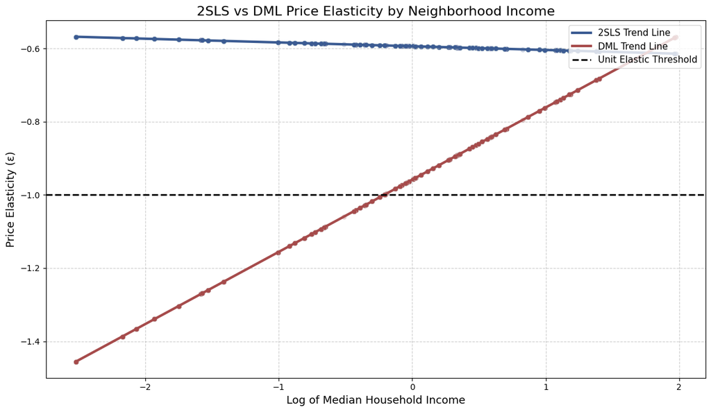

**Visual Insight:**  
The graphical comparison reinforces the stronger income-dependent elasticity variation recovered under DML-IV, where lower-income consumers exhibit substantially greater price responsiveness than higher-income consumers. In contrast, the near-uniform subgroup elasticities under 2SLS suggest limited detected heterogeneity across income segments.

## 6. Robustness & Validation

Diagnostic testing was conducted to assess identification strength and robustness for both estimation frameworks. Validation included instrument relevance, placebo validity, subsample stability, and sensitivity to control specification. Control sensitivity was assessed through competitor price removal, reduced control set estimation, and random noise augmentation.

## 6.1 Instrument Relevance

Instrument relevance was assessed by comparing model $R^2$ under both estimation frameworks with and without inclusion of the instrument. This comparison provides both the incremental change in $R^2$ and the corresponding percentage change, measuring the additional explanatory contribution of the instrument within each framework.

**▶ Show/Hide 2SLS Instrument Relevance Test Code**

```
# =========================
# 2SLS Instrument Relevance Test
# =========================

# --- FULL model (already have this) ---
ZW_full = np.hstack([Z_2sls, W_2sls])
beta_first_full = np.linalg.lstsq(ZW_full, T_2sls, rcond=None)[0]
T_hat = ZW_full @ beta_first_full

res_full = T_2sls - T_hat

# Total sum of squares (column-wise for 2 endogenous vars)
ss_total = np.sum((T_2sls - T_2sls.mean(axis=0))**2, axis=0)

# Residual sum of squares
ss_res_full = np.sum(res_full**2, axis=0)

r2_2sls_iv = 1 - (ss_res_full / ss_total)

# --- RESTRICTED model (NO instruments: regress T on W only) ---
beta_w = np.linalg.lstsq(W_2sls, T_2sls, rcond=None)[0]
T_hat_w = W_2sls @ beta_w

res_restricted = T_2sls - T_hat_w
ss_res_restricted = np.sum(res_restricted**2, axis=0)

r2_2sls_noiv = 1 - (ss_res_restricted / ss_total)

# --- Incremental R² ---
delta_r2_2sls = r2_2sls_iv - r2_2sls_noiv

# --- Partial R² (per endogenous variable) ---
pct_r2_2sls = (r2_2sls_iv - r2_2sls_noiv) / (1 - r2_2sls_noiv)
```

**▶ Show/Hide DML-IV Instrument Relevance Test Code**

```
# =========================
# DML-IV Instrument Relevance Test
# =========================
from sklearn.metrics import r2_score

XW  = np.column_stack([X_dml, W_dml])
XWZ = np.column_stack([X_dml, W_dml, Z_dml])

model_no_z = make_xgb(1)
model_with_z = make_xgb(1)

model_no_z.fit(XW, T_dml)
model_with_z.fit(XWZ, T_dml)

T_hat_no_z = model_no_z.predict(XW)
T_hat_with_z = model_with_z.predict(XWZ)

r2_dml_noiv = r2_score(T, T_hat_no_z)
r2_dml_iv = r2_score(T, T_hat_with_z)

delta_r2_dml = r2_dml_iv - r2_dml_noiv
pct_r2_dml = delta_r2_dml / (1 - r2_dml_noiv)
```

**▶ Show/Hide 2SLS & DML-IV Instrument Relevance Test Results Code**

```
# =========================
# 2SLS & DML-IV Instrument Relevance Test Results
# =========================

instrument_results = pd.DataFrame({
    "2SLS": [
        float(r2_2sls_noiv[0]),
        float(r2_2sls_iv[0]),
        float(delta_r2_2sls[0]),
        float(pct_r2_2sls[0] * 100)
    ],
    "DML-IV": [
        float(r2_dml_noiv),
        float(r2_dml_iv),
        float(delta_r2_dml),
        float(pct_r2_dml * 100)
    ]
},
index=[
    "R² (Without IV)",
    "R² (With IV)",
    "Incremental R²",
    "Percentage Change (%)"
])

instrument_results.round(2)

display(
    instrument_results.style
    .format("{:.2f}")
    .set_caption("Instrument Relevance Results")
    .set_table_styles([
        {
            'selector': 'caption',
            'props': [
                ('text-align', 'Center'),
                ('font-size', '16px'),
                ('font-weight', 'bold'),
                ('margin-bottom', '10px')
            ]
        },
        {
            'selector': '',
            'props': [
                ('margin-left', 'auto'),
                ('margin-right', 'auto')
            ]
        }
    ])
)
```

Instrument Relevance Results

|  | 2SLS | DML-IV |
| --- | --- | --- |
| R² (Without IV) | 0.83 | 0.92 |
| R² (With IV) | 0.96 | 0.98 |
| Incremental R² | 0.13 | 0.06 |
| Percentage Change (%) | 77.14 | 74.76 |

**Interpretation:**

Instrument inclusion produces substantial improvements in explanatory power under both estimation frameworks, with percentage $R^2$ increases of 77.14% under 2SLS and 74.76% under DML-IV. Although the absolute incremental $R^2$ gain is larger under 2SLS, this primarily reflects DML-IV’s higher baseline explanatory power prior to instrument inclusion. The similar relative improvements across frameworks provide strong evidence of instrument relevance and suggest that differences in estimated elasticities are unlikely to reflect weak instrument concerns.

## 6.2 Placebo Validity

Placebo validation was conducted by randomly shuffling the treatment variable (`ln_price_oz`) under both estimation frameworks, thereby removing the structured relationship between price and quantity (`ln_move`). The instrumental variable (`ln_cost_oz`) was shuffled using the same permutation to preserve alignment between the treatment and instrument while eliminating their original relationship with the outcome. Models were re-estimated across five randomized iterations, with resulting elasticity estimates averaged across runs. Under valid identification, placebo elasticities should converge toward zero, indicating that the estimation framework does not generate spurious causal effects when meaningful treatment variation is removed.

**▶ Show/Hide 2SLS Placebo Validity Code**

```
# =========================
# 2SLS Placebo Validity
# =========================

store_ids = model_df['STORE'].values
unique_stores = np.unique(store_ids)

placebo_elasticities_2sls = []
placebo_n = []

frac = 0.2

for seed in range(5):
    np.random.seed(seed)

    # Subsample stores
    sample_stores = np.random.choice(
        unique_stores,
        size=int(frac * len(unique_stores)),
        replace=False
    )

    mask = np.isin(store_ids, sample_stores)

    Y_s_2sls = Y_2sls[mask]
    T_s_2sls = T_2sls[mask]
    Z_s_2sls = Z_2sls[mask]
    W_s_2sls = W_2sls[mask]

    n_obs = Y_s_2sls.shape[0]

    # Placebo shuffle (T and Z together)
    perm = np.random.permutation(n_obs)

    T_p_2sls = T_s_2sls[perm]
    Z_p_2sls = Z_s_2sls[perm]

    # 2SLS Run
    beta_second, _ = run_2sls_full(
        Y_s_2sls,
        T_p_2sls,
        Z_p_2sls,
        W_s_2sls
    )

    elasticity_p = beta_second[0]

    # store
    placebo_elasticities_2sls.append(elasticity_p)
    placebo_n.append(n_obs)

placebo_elasticities_2sls = np.array(placebo_elasticities_2sls)
```

**▶ Show/Hide DML-IV Placebo Validity Code**

```
# =========================
# DML-IV Placebo Validity
# =========================

placebo_elasticities_dml = []
placebo_n_dml = []

stores = model_df['STORE'].unique()
frac = 0.2

for seed in range(5):
    np.random.seed(seed)

    # -------------------------
    # Subsample by STORE
    # -------------------------
    sample_stores = np.random.choice(
        stores,
        size=int(frac * len(stores)),
        replace=False
    )

    sample_df = model_df[model_df['STORE'].isin(sample_stores)].copy()
    sample_df = sample_df.reset_index(drop=True)

    n_obs = len(sample_df)

    # Build matrices
    Y_s_dml = sample_df['ln_move'].astype('float32')
    T_s_dml = sample_df['ln_price_per_oz'].astype('float32')
    Z_s_dml = sample_df['ln_cost_per_oz'].astype('float32')

    X_s_dml = sample_df[['ln_income_std']].astype('float32')

    W_s_dml = sample_df[
        ['ln_oz', 'AGE60', 'UNEMP', 'EDUC',
         'SALE_B', 'SALE_C', 'SALE_S', 'comp_price']
        + brand_cols
        + pack_cols
        + month_cols
    ].astype('float32')

    # -------------------------
    # Placebo shuffle (T and Z together)
    # -------------------------
    perm = np.random.permutation(n_obs)

    T_p_dml = T_s_dml.iloc[perm].reset_index(drop=True)
    Z_p_dml = Z_s_dml.iloc[perm].reset_index(drop=True)

    Y_p_dml = Y_s_dml.reset_index(drop=True)
    X_p_dml = X_s_dml.reset_index(drop=True)
    W_p_dml = W_s_dml.reset_index(drop=True)

    # -------------------------
    # Fit DML-IV
    # -------------------------
    est_placebo = DMLIV(
        model_y_xw=make_xgb(seed),
        model_t_xw=make_xgb(seed+1),
        model_t_xwz=make_xgb(seed+2),
        cv=5
    )

    est_placebo.fit(
        Y_p_dml,
        T_p_dml,
        Z=Z_p_dml,
        X=X_p_dml,
        W=W_p_dml
    )

    effects = est_placebo.effect(X_p_dml)
    mean_effect = effects.mean()

    # Store results
    placebo_elasticities_dml.append(mean_effect)
    placebo_n_dml.append(n_obs)

placebo_elasticities_dml = np.array(placebo_elasticities_dml)
```

**▶ Show/Hide 2SLS & DML-IV Placebo Validation Test Results Code**

```
# =========================
# 2SLS & DML-IV Placebo Validation Test Results
# =========================

placebo_results = pd.DataFrame({
    "2SLS": [
        float(placebo_elasticities_2sls.mean()),
        float(placebo_elasticities_2sls.std()),
        float(np.abs(placebo_elasticities_2sls).max()),
        float(np.abs(placebo_elasticities_2sls).min())
    ],
    "DML-IV": [
        float(placebo_elasticities_dml.mean()),
        float(placebo_elasticities_dml.std()),
        float(np.abs(placebo_elasticities_dml).max()),
        float(np.abs(placebo_elasticities_dml).min())
    ]
},
index=[
    "Mean Elasticity",
    "Std Elasticity",
    "Max |Elasticity|",
    "Min |Elasticity|"
])

placebo_results.round(4)

display(
    placebo_results.style
    .format("{:.4f}")
    .set_caption("Placebo Validation Results")
    .set_table_styles([
        {
            'selector': 'caption',
            'props': [
                ('text-align', 'center'),
                ('font-size', '16px'),
                ('font-weight', 'bold'),
                ('margin-bottom', '10px')
            ]
        },
        {
            'selector': '',
            'props': [
                ('margin-left', 'auto'),
                ('margin-right', 'auto')
            ]
        }
    ])
)
```

Placebo Validation Results

|  | 2SLS | DML-IV |
| --- | --- | --- |
| Mean Elasticity | 0.0016 | 0.0023 |
| Std Elasticity | 0.0036 | 0.0041 |
| Max \|Elasticity\| | 0.0057 | 0.0066 |
| Min \|Elasticity\| | 0.0011 | 0.0022 |

**Interpretation:**  
Placebo elasticities remain effectively zero under both estimation frameworks, indicating that the models do not recover meaningful causal effects when the treatment and instrument relationship is randomly reassigned. Elasticity dispersion and worst-case placebo deviations are also extremely small across repeated iterations, providing strong evidence that the estimated baseline effects are not driven by spurious correlation or model overfitting.

## 6.3 Subsample Stability

Subsample stability was evaluated by repeatedly estimating each framework across five independent 20% subsamples drawn at the store level. Sampling was performed by store rather than individual observation to preserve within-store correlation structure and assess whether elasticity estimates remain stable across distinct retail environments. The 20% sampling fraction introduces a meaningful perturbation to the estimation sample, while repeated draws provide evidence that observed elasticity behavior is not driven by any single subsample realization. Resulting subsample elasticities were compared against full-sample estimates, with limited deviation indicating stable causal estimation and robustness to sample composition.

**▶ Show/Hide Percentage Change Function Code**

```
# =========================
# Percentage change function used for following Subsample and Control Sensitivity Tests
# =========================

# Define %change function
def pct_change(new, base):
    return 100 * (new - base) / abs(base)
```

**▶ Show/Hide 2SLS Subsample Test Code**

```
# =========================
# 2SLS Subsample Test
# =========================

sub_elasticities_2sls = []
sub_pct_2sls = []
sub_n_2sls = []

store_ids = model_df['STORE'].to_numpy().reshape(-1)
unique_stores = np.unique(store_ids)

n_runs = 5
frac = 0.2

for seed in range(n_runs):
    np.random.seed(seed)

    # -------------------------
    # Sample stores
    # -------------------------
    sample_stores = np.random.choice(
        unique_stores,
        size=int(frac * len(unique_stores)),
        replace=False
    )

    mask = np.isin(store_ids, sample_stores)

    # Subsample arrays
    Y_s_2sls = Y_2sls[mask]
    T_s_2sls = T_2sls[mask]
    Z_s_2sls = Z_2sls[mask]
    W_s_2sls = W_2sls[mask]

    n_obs = Y_s_2sls.shape[0]

    # -------------------------
    # Run 2SLS
    # -------------------------
    beta_sub, _ = run_2sls_full(
        Y_s_2sls,
        T_s_2sls,
        Z_s_2sls,
        W_s_2sls
    )

    elasticity_sub = beta_sub[0]

    pct_diff = 100 * (
        elasticity_sub - elasticity_2sls
    ) / abs(elasticity_2sls)

    sub_elasticities_2sls.append(elasticity_sub)
    sub_pct_2sls.append(pct_diff)
    sub_n_2sls.append(n_obs)

sub_elasticities_2sls = np.array(sub_elasticities_2sls)
sub_pct_2sls = np.array(sub_pct_2sls)
```

**▶ Show/Hide DML-IV Subsample Test Code**

```
# =========================
# DML-IV Subsample Test
# =========================

sub_elasticities_dml = []
sub_pct_dml = []
sub_n_dml = []

stores = model_df['STORE'].unique()
n_runs = 5
frac = 0.2

for seed in range(n_runs):
    np.random.seed(seed)

    sample_stores = np.random.choice(
        stores,
        size=int(frac * len(stores)),
        replace=False
    )

    sample_df = model_df[model_df['STORE'].isin(sample_stores)].copy()
    sample_df = sample_df.reset_index(drop=True)

    n_obs = len(sample_df)

    # Rebuild matrices
    Y_s_dml = sample_df['ln_move'].astype('float32')
    T_s_dml = sample_df['ln_price_per_oz'].astype('float32')
    Z_s_dml = sample_df['ln_cost_per_oz'].astype('float32')

    X_s_dml = sample_df[['ln_income_std']].astype('float32')

    W_s_dml = sample_df[
        ['ln_oz', 'AGE60', 'UNEMP', 'EDUC',
         'SALE_B', 'SALE_C', 'SALE_S', 'comp_price']
        + brand_cols
        + pack_cols
        + month_cols
    ].astype('float32')

    est_sub = DMLIV(
        model_y_xw=make_xgb(41),
        model_t_xw=make_xgb(42),
        model_t_xwz=make_xgb(43),
        cv=5
    )

    est_sub.fit(Y_s_dml, T_s_dml, Z=Z_s_dml, X=X_s_dml, W=W_s_dml)

    elasticity_sub = est_sub.effect(X_s_dml).mean()

    pct_diff = pct_change(elasticity_sub, elasticity_dml)

    sub_elasticities_dml.append(elasticity_sub)
    sub_pct_dml.append(pct_diff)
    sub_n_dml.append(n_obs)

sub_elasticities_dml = np.array(sub_elasticities_dml)
sub_pct_dml = np.array(sub_pct_dml)
```

**▶ Show/Hide 2SLS & DML-IV Subsample Stability Test Results Code**

```
# =========================
# 2SLS & DML-IV Subsample Stability Test Results
# =========================

subsample_results = pd.DataFrame({
    "2SLS": [
        float(sub_elasticities_2sls.mean()),
        float(sub_elasticities_2sls.std()),
        float(sub_pct_2sls.mean()),
        float(sub_pct_2sls.std()),
        float(np.abs(sub_pct_2sls).max())
    ],
    "DML-IV": [
        float(sub_elasticities_dml.mean()),
        float(sub_elasticities_dml.std()),
        float(sub_pct_dml.mean()),
        float(sub_pct_dml.std()),
        float(np.abs(sub_pct_dml).max())
    ]
},
index=[
    "Mean Elasticity",
    "Std Elasticity",
    "Mean % Change",
    "Std % Change",
    "Max |% Change|"
])

subsample_results.round(4)

display(
    subsample_results.style
    .format("{:.4f}")
    .set_caption("Subsample Stability Results")
    .set_table_styles([
        {
            'selector': 'caption',
            'props': [
                ('text-align', 'Center'),
                ('font-size', '16px'),
                ('font-weight', 'bold'),
                ('margin-bottom', '10px')
            ]
        },
        {
            'selector': '',
            'props': [
                ('margin-left', 'auto'),
                ('margin-right', 'auto')
            ]
        }
    ])
)
```

Subsample Stability Results

|  | 2SLS | DML-IV |
| --- | --- | --- |
| Mean Elasticity | -0.6084 | -0.8991 |
| Std Elasticity | 0.0662 | 0.0516 |
| Mean % Change | -15921.5029 | 6.2046 |
| Std % Change | 1722.2469 | 5.3861 |
| Max \|% Change\| | 18688.0176 | 11.0817 |

## 6.4 Sensitivity to Control Specification

Sensitivity to control specification was evaluated to assess whether estimated elasticities are materially dependent on the chosen control set under either estimation framework. Three specification perturbations were examined: (1) removal of competitor price, (2) estimation using a reduced minimum control set, and (3) augmentation of the control set with a random noise variable. These tests evaluate whether elasticity estimates remain stable when economically relevant controls are omitted, model parsimony is imposed, or irrelevant information is introduced. Limited deviation across these alternative specifications provides evidence that estimated causal effects are not highly sensitive to specific control selection choices.

**6.4.1 Competitor Price Removal**  
Competitor price was excluded from the control set to assess whether estimated elasticities are materially dependent on explicit competitive market adjustment. Since competitor pricing may capture substitution dynamics and local competitive pressure, limited deviation from baseline estimates would indicate that estimated causal effects are not disproportionately driven by this specific control.

**▶ Show/Hide 2SLS Removal of Comp_price Code**

```
# =========================
# 2SLS Removal of Comp_price
# =========================

comp_idx = W_base_cols_2sls.index('comp_price')

W_base_no_comp_2sls = np.delete(
    W_base_2sls,
    comp_idx,
    axis=1
)

W_no_comp_2sls = np.hstack([
    const,
    W_base_no_comp_2sls,
    FE
])

beta_no_comp, _ = run_2sls_full(
    Y_2sls,
    T_2sls,
    Z_2sls,
    W_no_comp_2sls
)

elasticity_no_comp_2sls = beta_no_comp[0]
```

**▶ Show/Hide DML-IV Removal of Comp_price Code**

```
# =========================
#  DML-IV Removal of Comp_price
# =========================

# Find index of comp_price in W_base
comp_idx = W_dml_cols.index('comp_price')

# Remove comp_price from W_base
W_no_comp_dml = np.delete(W_dml, comp_idx, axis=1).astype(np.float32)

est_no_comp = DMLIV(
    model_y_xw=make_xgb(41),
    model_t_xw=make_xgb(42),
    model_t_xwz=make_xgb(43),
    discrete_treatment=False,
    cv=5
)

est_no_comp.fit(Y_dml, T_dml, Z=Z_dml, X=X_dml, W=W_no_comp_dml, inference=BootstrapInference(n_bootstrap_samples=1))
elasticity_no_comp_dml = est_no_comp.effect(X).mean()

elasticity_no_comp_dml = est_no_comp.effect(X).mean()
```

**▶ Show/Hide 2SLS & DML-IV Removal of Comp_price Test Results Code**

```
# =========================
# 2SLS & DML-IV Removal of Comp_price Test Results
# =========================

nocomp_results = pd.DataFrame({
    "2SLS": [
        float(elasticity_no_comp_2sls),
        float(pct_change(elasticity_no_comp_2sls, elasticity_2sls))
    ],
    "DML-IV": [
        float(elasticity_no_comp_dml),
        float(pct_change(elasticity_no_comp_dml, elasticity_dml))
    ]
},
index=[
    "Elasticity",
    "% Change"
])

nocomp_results.round(2)

display(
    nocomp_results.style
    .format("{:.2f}")
    .set_caption("Remove Competitors' Price Results")
    .set_table_styles([
        {
            'selector': 'caption',
            'props': [
                ('text-align', 'Center'),
                ('font-size', '16px'),
                ('font-weight', 'bold'),
                ('margin-bottom', '10px')
            ]
        },
        {
            'selector': '',
            'props': [
                ('margin-left', 'auto'),
                ('margin-right', 'auto')
            ]
        }
    ])
)
```

Remove Competitors' Price Results

|  | 2SLS | DML-IV |
| --- | --- | --- |
| Elasticity | -0.53 | -0.93 |
| % Change | 10.74 | 2.98 |

**Interpretation:**

**6.4.2 Reduced Minimum Control Set**  
A reduced minimum control specification was estimated to evaluate whether elasticity estimates remain stable under a more parsimonious modeling framework. By retaining only the most essential structural controls, this test assesses whether the baseline estimates depend on richer control information or remain robust under simplified specification.

**▶ Show/Hide 2SLS Minimal controls Code**

```
# =========================
# 2SLS Minimal controls
# =========================

min_cols = ['ln_oz', 'AGE60', 'UNEMP', 'EDUC']
min_idx = [W_base_cols_2sls.index(c) for c in min_cols]

W_base_min_2sls = W_base_2sls[:, min_idx]

W_min_2sls = np.hstack([
    const,
    W_base_min_2sls,
    FE
])

beta_min, _ = run_2sls_full(
    Y_2sls,
    T_2sls,
    Z_2sls,
    W_min_2sls
)

elasticity_w_min_2sls = beta_min[0]
```

**▶ Show/Hide DML-IV Minimal controls Code**

```
# =========================
# DML-IV Minimal controls
# =========================

min_cols = ['ln_oz', 'AGE60', 'UNEMP', 'EDUC']
min_idx = [W_dml_cols.index(c) for c in min_cols]

W_min_dml = np.hstack([
    W_dml[:, min_idx],            # selected baseline controls
    W_dml[:, len(W_dml_cols):]    # all FE columns
]).astype(np.float32)

est_w_min = DMLIV(
    model_y_xw=make_xgb(41),
    model_t_xw=make_xgb(42),
    model_t_xwz=make_xgb(43),
    discrete_treatment=False,
    cv=5
)

est_w_min.fit(Y_dml, T_dml, Z=Z_dml, X=X_dml, W=W_min_dml, inference=BootstrapInference(n_bootstrap_samples=1))
elasticity_w_min_dml = est_w_min.effect(X).mean()
```

**▶ Show/Hide 2SLS & DML-IV Minimum Controls Test Results Code**

```
# =========================
# 2SLS & DML-IV Minimum Controls Test Results
# =========================

nocomp_results = pd.DataFrame({
    "2SLS": [
        float(elasticity_w_min_2sls),
        float(pct_change(elasticity_w_min_2sls, elasticity_2sls))
    ],
    "DML-IV": [
        float(elasticity_w_min_dml),
        float(pct_change(elasticity_w_min_dml, elasticity_dml))
    ]
},
index=[
    "Elasticity",
    "% Change"
])

nocomp_results.round(2)

display(
    nocomp_results.style
    .format("{:.2f}")
    .set_caption("Reduced Minimum Control Set Results")
    .set_table_styles([
        {
            'selector': 'caption',
            'props': [
                ('text-align', 'Center'),
                ('font-size', '16px'),
                ('font-weight', 'bold'),
                ('margin-bottom', '10px')
            ]
        },
        {
            'selector': '',
            'props': [
                ('margin-left', 'auto'),
                ('margin-right', 'auto')
            ]
        }
    ])
)
```

Reduced Minimum Control Set Results

|  | 2SLS | DML-IV |
| --- | --- | --- |
| Elasticity | -0.39 | -1.35 |
| % Change | 34.13 | -40.47 |

**Interpretation:**

**6.4.3 Random Noise Augmentation**  
A randomly generated noise variable was added to the control set to assess robustness to irrelevant covariate inclusion. Because the added variable contains no economic information, meaningful changes in estimated elasticities would suggest excessive sensitivity to control set expansion, while limited deviation would indicate specification stability.

**▶ Show/Hide 2SLS Random Noise Augmentation Code**

```
# =========================
# 2SLS Random Noise Augmentation
# =========================

np.random.seed(0)

noise = np.random.normal(
    0,
    1,
    size=(Y_2sls.shape[0], 1)
).astype(np.float32)

W_noise_2sls = np.hstack([
    const,
    W_base_2sls,
    noise,
    FE
])

beta_noise, _ = run_2sls_full(
    Y_2sls,
    T_2sls,
    Z_2sls,
    W_noise_2sls
)

elasticity_noise_2sls = beta_noise[0]
```

**▶ Show/Hide DML-IV Random Noise Augmentation Code**

```
# =========================
# DML-IV Random Noise Augmentation
# =========================

# Set seed for reproducibility
np.random.seed(0)

# Generate noise column (n x 1)
noise_dml = np.random.normal(0, 1, size=(W_dml.shape[0], 1)).astype(np.float32)

# Append to W
W_with_noise_dml = np.hstack([W_dml, noise_dml]).astype(np.float32)

est_noise = DMLIV(model_y_xw=make_xgb(41),
                   model_t_xw=make_xgb(42),
                   model_t_xwz=make_xgb(43),
                   cv=5)

est_noise.fit(Y_dml, T_dml, Z=Z_dml, X=X_dml, W=W_with_noise_dml)
elasticity_noise_dml = est_noise.effect(X).mean()
```

**▶ Show/Hide 2SLS & DML-IV Random Noise Augmentation Test Results Code**

```
# =========================
# 2SLS & DML-IV Random Noise Augmentation Test Results
# =========================

nocomp_results = pd.DataFrame({
    "2SLS": [
        float(elasticity_noise_2sls),
        float(pct_change(elasticity_noise_2sls, elasticity_2sls))
    ],
    "DML-IV": [
        float(elasticity_noise_dml),
        float(pct_change(elasticity_noise_dml, elasticity_dml))
    ]
},
index=[
    "Elasticity",
    "% Change"
])

nocomp_results.round(5)

display(
    nocomp_results.style
    .format("{:.5f}")
    .set_caption("Random Noise Augmentation Results")
    .set_table_styles([
        {
            'selector': 'caption',
            'props': [
                ('text-align', 'Center'),
                ('font-size', '16px'),
                ('font-weight', 'bold'),
                ('margin-bottom', '10px')
            ]
        },
        {
            'selector': '',
            'props': [
                ('margin-left', 'auto'),
                ('margin-right', 'auto')
            ]
        }
    ])
)
```

Random Noise Augmentation Results

|  | 2SLS | DML-IV |
| --- | --- | --- |
| Elasticity | -0.59394 | -0.95202 |
| % Change | -0.00002 | 0.68118 |

**Interpretation:**

Addition of a random noise variable produces negligible elasticity deviation under both estimation frameworks, indicating strong robustness to irrelevant covariate inclusion. Elasticity changes remain effectively zero under 2SLS and below 1% under DML-IV, suggesting that neither framework is materially sensitive to non-informative control expansion. These results provide evidence that the baseline estimates are not driven by overfitting to arbitrary control variation.

## 7. Pricing Policy Simulation

This section translates estimated elasticity differences into actionable pricing recommendations through two pricing simulations. The first applies a constrained elasticity-based pricing rule derived from standard demand theory to evaluate theoretically implied profit-maximizing price adjustments. The resulting limitations motivate a second simulation, which introduces a bounded income-based pricing strategy designed to better reflect practical retail pricing constraints. Together, these simulations illustrate both the opportunities and limitations of translating causal elasticity estimates into operational pricing policy.

## 7.1 Constrained Elasticity-Based Price Optimization

The first pricing simulation applies the Lerner pricing condition to translate estimated elasticity values into store-level optimal price recommendations.

$$ \frac{P - MC}{P} = -\frac{1}{\epsilon} $$

where:

- $P$ = Optimal product price
- $MC$ = Marginal cost (proxied by observed unit cost)
- $\epsilon$ = Estimated own-price elasticity of demand

Further constraints are imposed to prevent implausible price recommendations in regions where the theoretical pricing condition becomes unstable. Specifically, optimal prices are bounded between 70% and 130% of observed prices to enforce realistic adjustment limits, while observations estimated to lie within the inelastic demand region are assigned a conservative heuristic price increase of 5% rather than applying the Lerner condition directly.

This approach provides a theoretical benchmark for evaluating how directly estimated elasticities can be translated into operational pricing decisions.

Simulated profit lift is then calculated by evaluating the demand function at the optimized price to recover the corresponding counterfactual quantity, allowing profit under the adjusted pricing policy to be compared directly with observed baseline performance.

**▶ Show/Hide Constrained Elasticity-Based Pricing Code**

[output not shown]

**▶ Show/Hide Constrained Elasticity-Based Pricing Results Code**

```
# =========================
# Constrained Elasticity-Based Pricing Results
# =========================

pricing_results = pd.DataFrame({
    "Metric": [
        "Baseline Profit",
        "Optimized Profit",
        "Total Profit Lift",
        "Profit Lift (%)",
        "Profit Lift (% Revenue)",
        "Mean Price Change (%)",
        "Median Price Change (%)"
    ],
    "Value": [
        baseline_profit,
        model_df['profit_opt_ceps'].sum(),
        total_lift_ceps,
        lift_pct_ceps * 100,
        lift_pct_revenue_ceps * 100,
        mean_price_change_ceps,
        median_price_change_ceps
    ]
})

display(
    pricing_results.style
    .hide(axis="index")
    .format({
        "Value": lambda x: (
            f"${x:,.0f}" if abs(x) > 1000
            else f"{x:.2f}%"
        )
    })
    .set_caption("Constrained Elasticity-Based Pricing Results")
    .set_table_styles([
        {
            'selector': 'caption',
            'props': [
                ('text-align', 'center'),
                ('font-size', '16px'),
                ('font-weight', 'bold'),
                ('margin-bottom', '10px')
            ]
        },
        {
            'selector': '',
            'props': [
                ('margin-left', 'auto'),
                ('margin-right', 'auto')
            ]
        },
        {
            'selector': 'th',
            'props': [('text-align', 'center')]
        },
        {
            'selector': 'td',
            'props': [('text-align', 'center')]
        }
    ])
)
```

Constrained Elasticity-Based Pricing Results

| Metric | Value |
| --- | --- |
| Baseline Profit | $6,448,267 |
| Optimized Profit | $13,990,878 |
| Total Profit Lift | $7,542,611 |
| Profit Lift (%) | 116.97% |
| Profit Lift (% Revenue) | 10.03% |
| Mean Price Change (%) | 0.14% |
| Median Price Change (%) | 0.05% |

**▶ Show/Hide Price Change Distribution of Constrained Elasticity-Based Pricing Code**

```
# =========================
# Distribution of Recommended Price Change
# Constrained Elasticity-Based Pricing
# =========================

import matplotlib.pyplot as plt

model_df['price_change_pct_ceps'] = (
    (model_df['p_opt_ceps'] / model_df['PRICE'] - 1) * 100
)

upper_clip_share = (
    (model_df['p_opt_ceps'] >= model_df['PRICE'] * 1.30).mean()
) * 100

lower_clip_share = (
    (model_df['p_opt_ceps'] <= model_df['PRICE'] * 0.70).mean()
) * 100

mean_change = model_df['price_change_pct_ceps'].mean()

plt.figure(figsize=(13, 6))

counts, bins, patches = plt.hist(
    model_df['price_change_pct_ceps'],
    bins=100,
    alpha=0.8
)

ymax = counts.max()

# Bounds
plt.axvline(
    30,
    linestyle='--',
    linewidth=2,
    label=f'Upper Bound (+30%)'
)

plt.axvline(
    -30,
    linestyle='--',
    linewidth=2,
    label=f'Lower Bound (-30%)'
)

plt.axvline(
    mean_change,
    linewidth=2,
    label=f'Mean ({mean_change:.2f}%)'
)

# Annotations
plt.text(
    30,
    ymax * 0.92,
    f'{upper_clip_share:.2f}% clipped',
    ha='right'
)

plt.text(
    -30,
    ymax * 0.85,
    f'{lower_clip_share:.2f}% clipped',
    ha='left'
)

plt.title("Distribution of Recommended Price Changes")
plt.xlabel("Recommended Price Change (%)")
plt.ylabel("Frequency")
plt.legend()
plt.tight_layout()
plt.show()
```

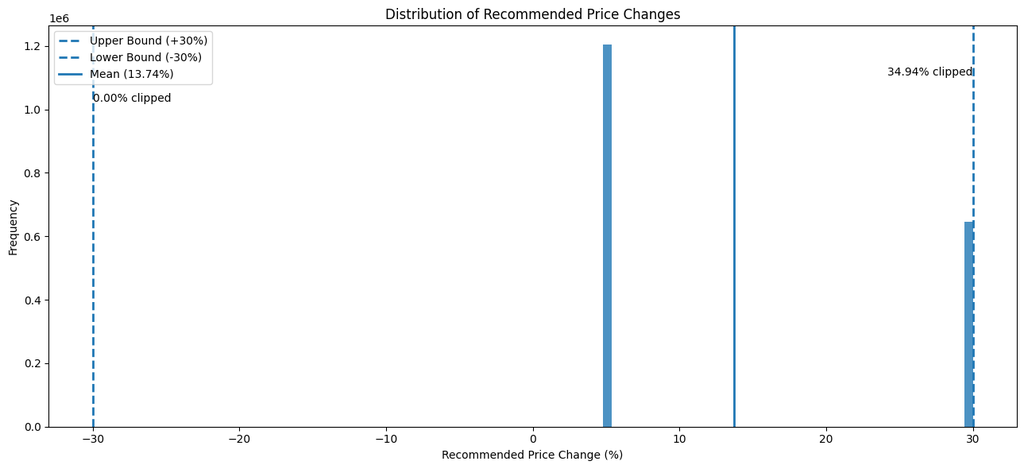

**Interpretation:**

The constrained elasticity-based optimization produces substantial simulated profit gains, indicating strong theoretical pricing opportunities implied by the estimated demand structure. However, recommended adjustments cluster heavily at the imposed upper pricing bound, with 34.94% of observations reaching the maximum allowable increase. This concentration suggests that elasticity-implied optimization frequently recommends larger adjustments than operationally feasible. The results therefore appear sensitive to extrapolation beyond observed pricing support, as the simulation assumes constant elasticity even though consumer responsiveness may shift once prices cross behavioral thresholds or trigger stronger substitution responses. As such, these gains are best interpreted as an upper-bound theoretical benchmark rather than directly realizable operational outcomes.

## 7.2 Bounded Income-Based Pricing Strategy

To address the extrapolation limitations of direct elasticity-based optimization, a second pricing simulation introduces a bounded income-based pricing strategy designed to preserve heterogeneous pricing recommendations while maintaining operational realism. Rather than directly extrapolating elasticity-implied optimal prices, this approach maps store-level income distributions into bounded price increases ranging from 1% to 3%. These adjustments are assigned through a sigmoid transformation rather than a linear mapping, allowing recommendations to vary smoothly across income segments while tapering at the extremes of the income distribution, where consumer responsiveness is less likely to scale proportionally with purchasing power.

The bounded income-based pricing adjustment is determined by the following sigmoid transformation:

$$ \Delta P_i = \delta_{min} + (\delta_{max} - \delta_{min}) \cdot \frac{1}{1 + e^{-k(x_i - x_0)}} $$

where:

- $\Delta P_i$ = Recommended percentage price adjustment for store $i$
- $\delta_{min}$ = Minimum price increase (1%)
- $\delta_{max}$ = Maximum price increase (3%)
- $x_i$ = Standardized store income
- $x_0$ = Income midpoint
- $k$ = Slope parameter controlling pricing sensitivity

The implied nonlinear pricing response across the Sigmoid transformation income distribution is visualized below.

**▶ Show/Hide Sigmoid Income-Based Pricing Transformation Code**

```
# =========================
# Sigmoid Income-Based Pricing Transformation
# =========================

import matplotlib.pyplot as plt
import numpy as np

x = np.linspace(-3, 3, 500)

delta_min = 0.01
delta_max = 0.03
x0 = 0
k = 5

price_adj = delta_min + (
    (delta_max - delta_min) /
    (1 + np.exp(-k * (x - x0)))
)

plt.figure(figsize=(12, 6))

plt.plot(
    x,
    price_adj * 100,
    linewidth=3
)

plt.axhline(1, linestyle='--', label='Minimum (1%)')
plt.axhline(3, linestyle='--', label='Maximum (3%)')
plt.axvline(0, linestyle=':', label='Income Midpoint')

plt.title("Income-Based Sigmoid Pricing Transformation")
plt.xlabel("Standardized Income")
plt.ylabel("Recommended Price Increase (%)")
plt.legend()

plt.tight_layout()
plt.show()
```

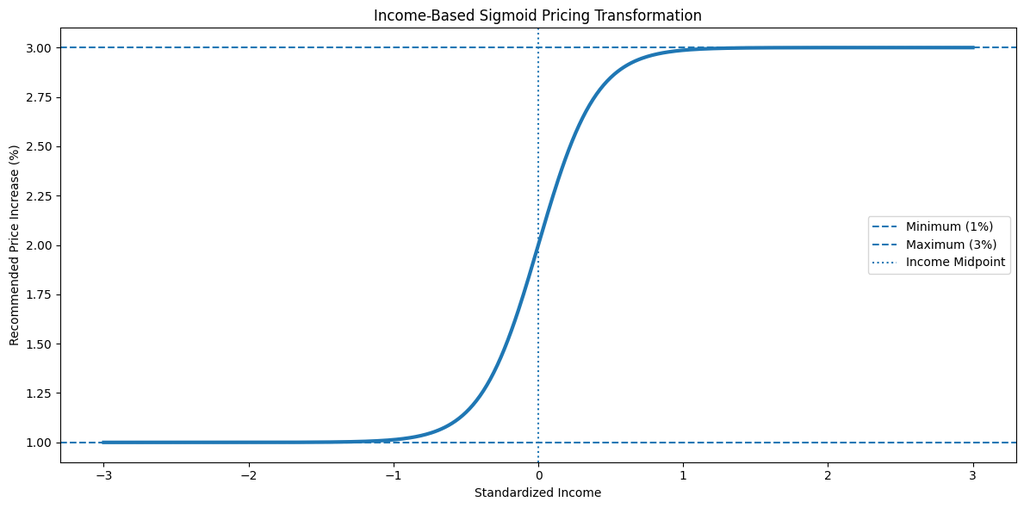

As shown, pricing adjustments increase most rapidly near the center of the income distribution while tapering toward both bounds, ensuring gradual differentiation without extreme recommendations at either tail.

This specification generates smooth, operationally bounded pricing adjustments across the income distribution, assigning larger increases to higher-income markets in accordance with the lower estimated price sensitivity recovered under the DML-IV heterogeneity results. Simulated profit lift is then calculated using the same counterfactual demand reconstruction framework employed in the previous pricing strategy.

**▶ Show/Hide Bounded Income-Based Pricing Code**

```
# =========================
# Bounded Income-Based Pricing
# =========================

# -------------------------
# 1. Row-level elasticities
# -------------------------
model_df['elasticity'] = est.effect(X).flatten().astype(np.float32)

# -------------------------
# 2. Normalize income
# -------------------------
inc_min = model_df['ln_income_std'].min()
inc_max = model_df['ln_income_std'].max()

model_df['inc_norm'] = (
    (model_df['ln_income_std'] - inc_min) /
    (inc_max - inc_min)
)

# -------------------------
# 3. Sigmoid income mapping
# -------------------------
k = 5

model_df['sigmoid'] = 1 / (
    1 + np.exp(-k * (model_df['inc_norm'] - 0.5))
)

# -------------------------
# 4. Map to 1–3% price increase
# -------------------------
low = 0.01
high = 0.03

model_df['pct_change_bips'] = (
    low + (high - low) * model_df['sigmoid']
)

# -------------------------
# 5. Collapse to STORE x UPC
# One pricing decision per product-store
# -------------------------
panel = model_df.groupby(['STORE', 'UPC']).apply(
    lambda g: pd.Series({
        'PRICE': np.average(g['PRICE'], weights=g['MOVE']),
        'COST': np.average(g['COST'], weights=g['MOVE']),
        'MOVE': g['MOVE'].sum(),
        'pct_change_bips': np.average(g['pct_change_bips'], weights=g['MOVE']),
        'elasticity': np.average(g['elasticity'], weights=g['MOVE'])
    })
).reset_index()

# -------------------------
# 6. Apply pricing policy
# -------------------------
panel['p_opt_bips'] = (
    panel['PRICE'] * (1 + panel['pct_change_bips'])
)

# -------------------------
# 7. Demand response
# Local elasticity approximation
# -------------------------
panel['Q_opt_bips'] = panel['MOVE'] * (
    1 + panel['elasticity'] * panel['pct_change_bips']
)

# Conservative quantity bounds
panel['Q_opt_bips'] = panel['Q_opt_bips'].clip(
    lower=panel['MOVE'] * 0.90,
    upper=panel['MOVE'] * 1.03
)

# -------------------------
# 8. Profit calculations
# -------------------------
panel['profit_current'] = (
    (panel['PRICE'] - panel['COST']) *
    panel['MOVE']
)

panel['profit_opt_bips'] = (
    (panel['p_opt_bips'] - panel['COST']) *
    panel['Q_opt_bips']
)

panel['profit_lift_bips'] = (
    panel['profit_opt_bips'] -
    panel['profit_current']
)

# -------------------------
# 9. Aggregate results
# -------------------------
total_lift_bips = panel['profit_lift_bips'].sum()

baseline_profit = panel['profit_current'].sum()
optimized_profit_bips = panel['profit_opt_bips'].sum()

lift_pct_profit_bips = total_lift_bips / baseline_profit

revenue = (
    panel['PRICE'] * panel['MOVE']
).sum()

lift_pct_revenue_bips = total_lift_bips / revenue

mean_price_change_bips = panel['pct_change_bips'].mean() * 100
median_price_change_bips = panel['pct_change_bips'].median() * 100
```

**▶ Show/Hide Bounded Income-Based Pricing Results Code**

```
# =========================
# Bounded Income-Based Pricing Results
# =========================

pricing_results = pd.DataFrame({
    "Metric": [
        "Baseline Profit",
        "Optimized Profit",
        "Total Profit Lift",
        "Profit Lift (%)",
        "Profit Lift (% Revenue)",
        "Mean Price Change (%)",
        "Median Price Change (%)"
    ],
    "Value": [
        baseline_profit,
        optimized_profit_bips,
        total_lift_bips,
        lift_pct_profit_bips * 100,
        lift_pct_revenue_bips * 100,
        mean_price_change_bips,
        median_price_change_bips
    ]
})

display(
    pricing_results.style
    .hide(axis="index")
    .format({
        "Value": lambda x: (
            f"${x:,.0f}" if abs(x) > 1000
            else f"{x:.2f}%"
        )
    })
    .set_caption("Bounded Income-Based Pricing Results")
    .set_table_styles([
        {
            'selector': 'caption',
            'props': [
                ('text-align', 'center'),
                ('font-size', '16px'),
                ('font-weight', 'bold'),
                ('margin-bottom', '10px')
            ]
        },
        {
            'selector': '',
            'props': [
                ('margin-left', 'auto'),
                ('margin-right', 'auto')
            ]
        },
        {
            'selector': 'th',
            'props': [('text-align', 'center')]
        },
        {
            'selector': 'td',
            'props': [('text-align', 'center')]
        }
    ])
)
```

Bounded Income-Based Pricing Results

| Metric | Value |
| --- | --- |
| Baseline Profit | $6,448,267 |
| Optimized Profit | $7,879,001 |
| Total Profit Lift | $1,430,733 |
| Profit Lift (%) | 22.19% |
| Profit Lift (% Revenue) | 1.90% |
| Mean Price Change (%) | 2.14% |
| Median Price Change (%) | 2.21% |

**▶ Show/Hide Price Change Distribution of Bounded Income-Based Pricing Code**

```
# =========================
# Distribution of Recommended Price Changes
# Bounded Income-Based Pricing
# =========================

import matplotlib.pyplot as plt

# Convert to %
panel['price_change_pct_bips'] = panel['pct_change_bips'] * 100

mean_change = panel['price_change_pct_bips'].mean()
median_change = panel['price_change_pct_bips'].median()

plt.figure(figsize=(12, 6))

counts, bins, patches = plt.hist(
    panel['price_change_pct_bips'],
    bins=50,
    alpha=0.8
)

ymax = counts.max()

# Bounds
plt.axvline(
    1,
    linestyle='--',
    linewidth=2,
    label='Lower Bound (1%)'
)

plt.axvline(
    3,
    linestyle='--',
    linewidth=2,
    label='Upper Bound (3%)'
)

# Mean
plt.axvline(
    mean_change,
    linewidth=2,
    label=f'Mean ({mean_change:.2f}%)'
)

# Median
plt.axvline(
    median_change,
    linewidth=2,
    linestyle=':',
    label=f'Median ({median_change:.2f}%)'
)

# Labels
plt.text(
    1,
    ymax * 0.92,
    "Minimum",
    ha='left'
)

plt.text(
    3,
    ymax * 0.92,
    "Maximum",
    ha='right'
)

plt.title("Distribution of Recommended Price Changes (Bounded Income-Based Pricing Strategy)")
plt.xlabel("Recommended Price Change (%)")
plt.ylabel("Frequency")
plt.legend()
plt.tight_layout()
plt.show()
```

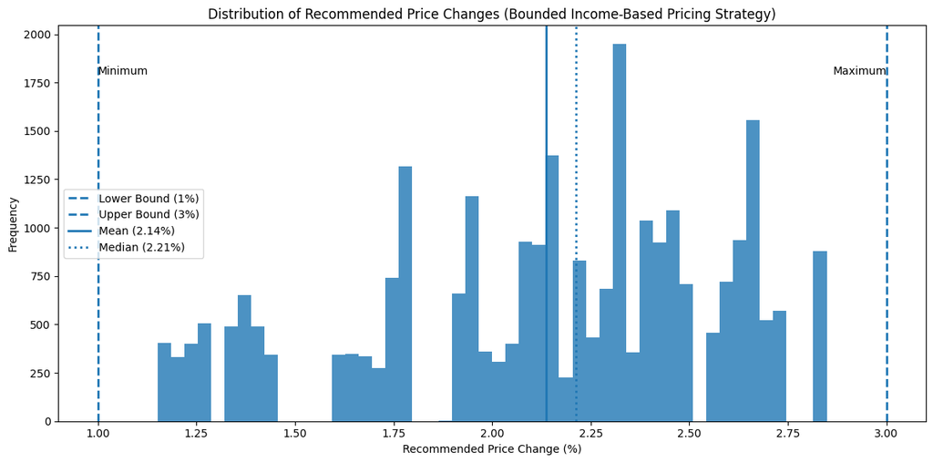

**Interpretation:**

The bounded income-based pricing strategy produces substantial simulated profit gains while maintaining operationally moderate price adjustments. With average recommended increases of approximately 2.14%, the strategy generates a 22.19% profit improvement without relying on the aggressive extrapolation observed under the direct elasticity-based optimization framework. The distribution of recommended adjustments is broadly dispersed across the feasible 1–3% pricing range, with no concentration at imposed operational boundaries. This indicates that the sigmoid transformation translates causal heterogeneity into stable pricing recommendations rather than mechanically pushing prices toward constraint limits. Together, these results suggest that bounded nonlinear pricing adjustments provide a more operationally credible mechanism for converting elasticity estimates into implementable pricing policy.

## 8. Key Findings & Takeaways

## 8.1 DML-IV Captures Richer Demand Structure

DML-IV recovered substantially stronger price responsiveness and more economically meaningful heterogeneity than the traditional 2SLS framework. While both approaches identified negative own-price elasticities, only DML-IV revealed a clear income-based pattern in which lower-income consumers exhibited greater price sensitivity than higher-income consumers. This result aligns closely with standard demand theory and likely reflects DML-IV’s ability to flexibly model nonlinear confounding structure and heterogeneous treatment effects that are difficult to recover under linear specifications.

## 8.2 Pricing Translation Requires Operational Constraints

The pricing simulations demonstrate that strong causal elasticity estimates do not automatically translate into directly implementable pricing policy. Direct elasticity-based optimization generated substantial theoretical profit gains but proved highly sensitive to extrapolation beyond observed pricing support. The bounded income-based pricing strategy provided a more operationally credible alternative, preserving heterogeneity-driven pricing differentiation while generating substantial simulated profit improvements under moderate price adjustments. These results highlight the importance of pairing causal demand estimation with realistic implementation constraints when translating inference into pricing decisions.

## 8.3 Causal Machine Learning Extends Classical Econometric Analysis

This project demonstrates the value of integrating machine learning with traditional econometric identification strategies. By combining flexible nuisance estimation with instrumental variable structure, DML-IV preserves the causal rigor of classical econometrics while substantially expanding the ability to recover nonlinear behavioral responses and heterogeneous treatment effects. More broadly, the findings suggest that causal machine learning is most powerful when deployed as a complement to economic theory, enhancing both interpretability and policy relevance in modern applied causal analysis.